# Quality Control

Yoshinori Hayakawa

## Quality Control

### Objective

Prior to conducting the basic Seurat analysis workflow, perform quality control (QC) to remove low-quality cells.

### Quality Control Workflow

1. Automated quality control using “ddqc”
2. Removal of doublet cells using “DoubletFinder”

#### Load Required Libraries

```r
# Load necessary libraries
library(Seurat)
library(tidyverse)       # Includes dplyr, ggplot2, etc.

library(ddqcR)           # Automated Quality Control tool
library(DoubletFinder)   # Doublet removal tool
```

#### Load Data

```r
# Load the Seurat object containing cell metadata
created_seurat_obj_list <- readRDS("./output/01_load/obj/created_seurat_obj_list.RDS")

# Load the original expression matrix without preprocessing
orig_mtx_list <- readRDS("./output/01_load/obj/orig_mtx_list.RDS")
```

#### Calculate the Proportion of Mitochondrial and Ribosomal Genes

Before conducting QC, calculate the proportions of mitochondrial and ribosomal genes.

```r
for(smn in names(created_seurat_obj_list)) {
  # Mitochondrial gene percentage
  created_seurat_obj_list[[smn]][["bfqc_percent.mt"]] <-
    PercentageFeatureSet(created_seurat_obj_list[[smn]], pattern = "^mt-")

  # Ribosomal gene percentage
  created_seurat_obj_list[[smn]][["bfqc_percent.rp"]] <-
    PercentageFeatureSet(created_seurat_obj_list[[smn]], pattern = "(?i)^RP[SL][[:digit:]]|^RPLP[[:digit:]]|^RPSA")
}
```

#### Automated Quality Control using ddqc

- **Filtering criteria:**
  - Cells with values significantly higher (percent.mito) or lower (nCount_RNA, nFeature_RNA) than x MADs (Median Absolute Deviation, default x = 2) from the cluster median are removed.
  - If the computed threshold within a cluster is greater than 200 for nFeature_RNA or less than 10% for percent.mito, they are set to 200 and 10%, respectively.
- **Generated plots:**
  - A log2-scaled nFeature_RNA distribution per cluster with a red line at 200 genes (log2 scale: 7.64).
  - A mitochondrial gene percentage distribution per cluster with a red line at 10%.

```r
ddqc_seurat_obj_list <- list()
ddqc_df_list <- list()

for(smn in names(created_seurat_obj_list)){
  print(paste0("ddqc: ", smn))
  tmpdata <- initialQC(created_seurat_obj_list[[smn]])
  ddqc_df_list[[smn]] <- ddqc.metrics(tmpdata)
  ddqc_seurat_obj_list[[smn]] <- filterData(tmpdata, ddqc_df_list[[smn]])
}
```

```
## [1] "ddqc: P1_cortex_WT"
```

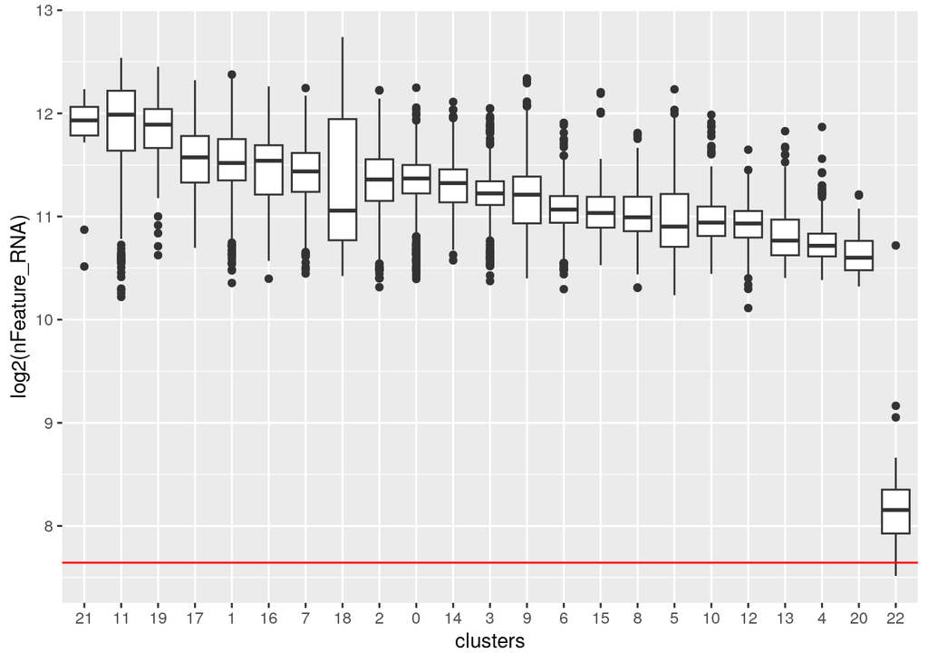

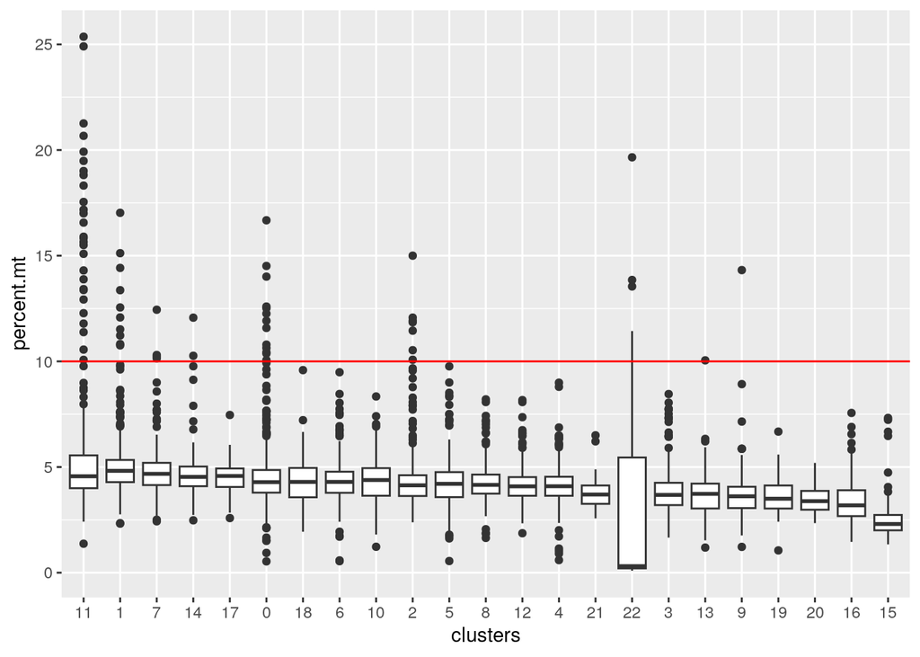

```
## [1] "ddqc: P1_cortex_Fezf2KO"
```

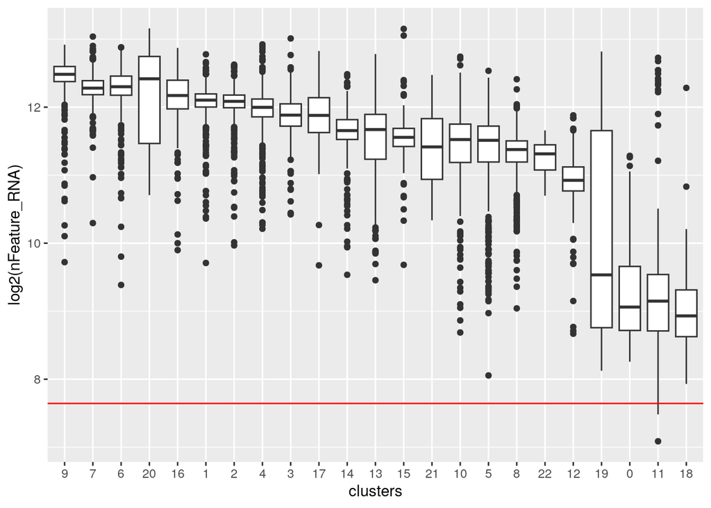

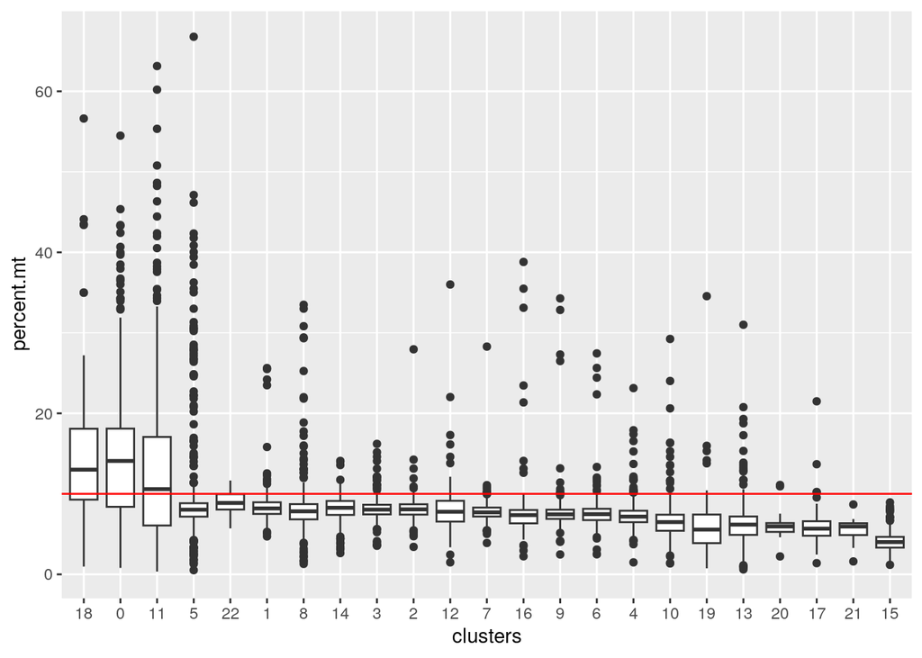

Check the updated metadata:

```r
head(ddqc_seurat_obj_list[[1]][[]])
```

|  | orig.ident | nCount_RNA | nFeature_RNA | age | area | condition | sample_name | bfqc_percent.mt | bfqc_percent.rp | percent.mt | percent.rb |
| --- | --- | --- | --- | --- | --- | --- | --- | --- | --- | --- | --- |
| AAACCTGAGAGCTTCT-1 | P1_cortex_WT | 6800 | 2555 | P1 | cortex | WT | P1_cortex_WT | 5.500000 | 12.97059 | 5.500000 | 12.97059 |
| AAACCTGAGAGTACCG-1 | P1_cortex_WT | 3213 | 1489 | P1 | cortex | WT | P1_cortex_WT | 8.652350 | 14.97043 | 8.652350 | 14.97043 |
| AAACCTGAGCCCTAAT-1 | P1_cortex_WT | 4086 | 1910 | P1 | cortex | WT | P1_cortex_WT | 2.422907 | 14.56192 | 2.422907 | 14.56192 |
| AAACCTGAGTGGGATC-1 | P1_cortex_WT | 4511 | 1926 | P1 | cortex | WT | P1_cortex_WT | 5.320328 | 13.56684 | 5.320328 | 13.56684 |
| AAACCTGCACAACTGT-1 | P1_cortex_WT | 8405 | 2892 | P1 | cortex | WT | P1_cortex_WT | 4.592504 | 17.65616 | 4.592504 | 17.65616 |
| AAACCTGCACAAGCCC-1 | P1_cortex_WT | 5380 | 2304 | P1 | cortex | WT | P1_cortex_WT | 3.197026 | 11.74721 | 3.197026 | 11.74721 |

Save the filtered Seurat objects:

```r
saveRDS(ddqc_seurat_obj_list, "./output/02_quality_control/obj/ddqc_seurat_obj_list.RDS")
saveRDS(ddqc_df_list, "./output/02_quality_control/obj/ddqc_df_list.RDS")
```

#### Doublet Removal using DoubletFinder

##### Preprocessing for Doublet Detection

Before running “DoubletFinder”, a basic Seurat analysis workflow must be performed:

```r
for_doubletfinder_seurat_obj_list <- lapply(ddqc_seurat_obj_list, NormalizeData)
for_doubletfinder_seurat_obj_list <- lapply(for_doubletfinder_seurat_obj_list, FindVariableFeatures)
for_doubletfinder_seurat_obj_list <- lapply(for_doubletfinder_seurat_obj_list, ScaleData)
for_doubletfinder_seurat_obj_list <- lapply(for_doubletfinder_seurat_obj_list, RunPCA)
for_doubletfinder_seurat_obj_list <- lapply(for_doubletfinder_seurat_obj_list, RunUMAP, dims = 1:10)
for_doubletfinder_seurat_obj_list <- lapply(for_doubletfinder_seurat_obj_list, FindNeighbors)
for_doubletfinder_seurat_obj_list <- lapply(for_doubletfinder_seurat_obj_list, FindClusters)
```

```
## Modularity Optimizer version 1.3.0 by Ludo Waltman and Nees Jan van Eck
##
## Number of nodes: 6398
## Number of edges: 227149
##
## Running Louvain algorithm...
## Maximum modularity in 10 random starts: 0.8837
## Number of communities: 18
## Elapsed time: 0 seconds
## Modularity Optimizer version 1.3.0 by Ludo Waltman and Nees Jan van Eck
##
## Number of nodes: 7795
## Number of edges: 269490
##
## Running Louvain algorithm...
## Maximum modularity in 10 random starts: 0.9108
## Number of communities: 20
## Elapsed time: 0 seconds
```

##### Detecting Doublets with DoubletFinder

```r
set.seed(1)
doublet_finder_res_df_list <- list()

for(nm in names(for_doubletfinder_seurat_obj_list)){
  print(paste0("DoubletFinder: ", nm))
  tmp_seurat_obj <- for_doubletfinder_seurat_obj_list[[nm]]

  sweep.res.list_pmbc <- paramSweep(tmp_seurat_obj, PCs = 1:10, sct = FALSE)
  sweep.stats_pmbc <- summarizeSweep(sweep.res.list_pmbc, GT = FALSE)
  bcmvn_pmbc <- find.pK(sweep.stats_pmbc)

  homotypic.prop <- modelHomotypic(tmp_seurat_obj[[]]$seurat_clusters)
  nExp_poi <- round(0.075 * nrow(tmp_seurat_obj[[]]))
  nExp_poi.adj <- round(nExp_poi * (1 - homotypic.prop))

  pN <- 0.25
  pK <- bcmvn_pmbc %>% arrange(desc(BCmetric)) %>% pull(pK) %>% as.character %>% as.numeric %>% .[1]

  base_char <- paste("DF.classifications", pN, pK, nExp_poi, sep = "_")
  adj_char  <- paste("DF.classifications", pN, pK, nExp_poi.adj, sep = "_")
  char_reuse_pANN <- paste("pANN", pN, pK, nExp_poi, sep = "_")

  tmp_seurat_obj <- doubletFinder(tmp_seurat_obj, PCs = 1:10, pN = pN, pK = pK, nExp = nExp_poi, reuse.pANN = FALSE, sct = FALSE)
  tmp_seurat_obj <- doubletFinder(tmp_seurat_obj, PCs = 1:10, pN = pN, pK = pK, nExp = nExp_poi.adj, reuse.pANN = char_reuse_pANN, sct = FALSE)

  tmp_doublet_finder_res_df <- tmp_seurat_obj[[]][c(base_char, adj_char)]
  colnames(tmp_doublet_finder_res_df) <- c("double_flg", "doublet_adj_flg")
  doublet_finder_res_df_list[[nm]] <- tmp_doublet_finder_res_df
}
```

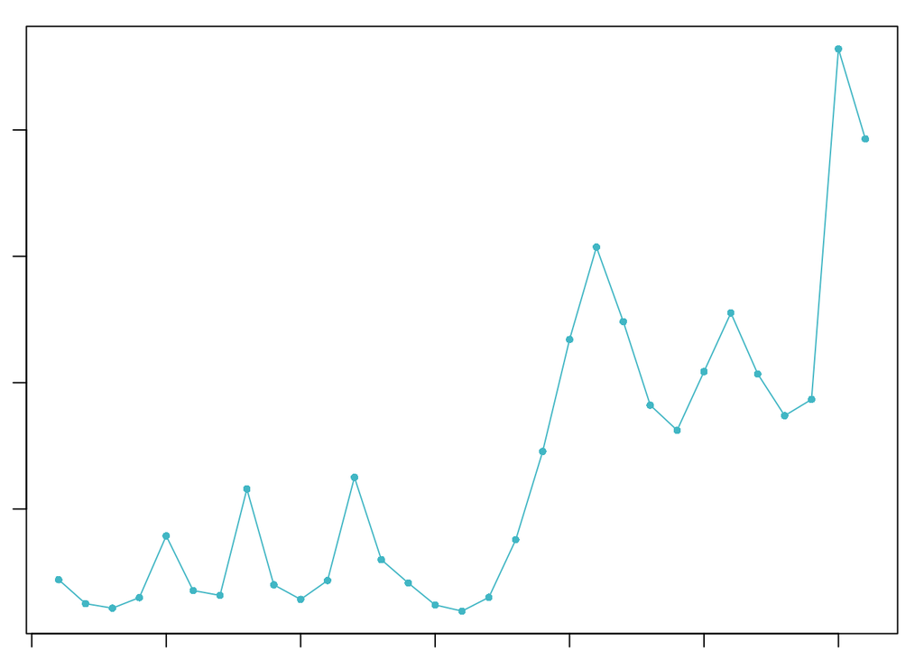

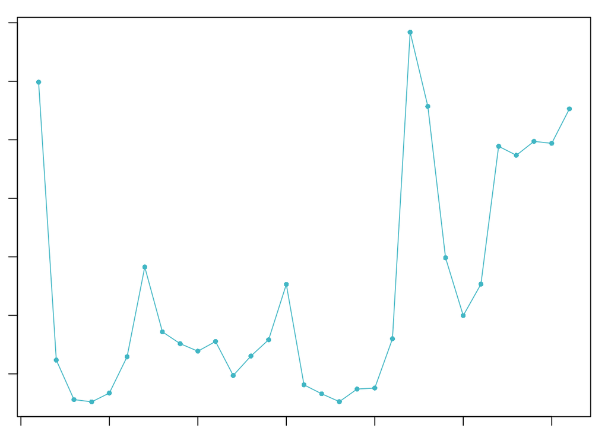

##### Removing Cells Identified as Doublets by “DoubleFinder”

```r
# code:2-9
doubletfinder_ddqc_seurat_obj_list <- list()
for (nm in names(ddqc_seurat_obj_list)) {
  # Add DoubletFinder results to metadata.
  doubletfinder_ddqc_seurat_obj_list[[nm]] <-
    AddMetaData(
      ddqc_seurat_obj_list[[nm]],
      doublet_finder_res_df_list[[nm]]
    )
  # Extract only cells identified as singlets by DoubletFinder.
  doubletfinder_ddqc_seurat_obj_list[[nm]] <- subset(doubletfinder_ddqc_seurat_obj_list[[nm]], subset = doublet_adj_flg %in% c("Singlet"))
}

# Verify metadata to ensure DoubletFinder results have been added.
head(doubletfinder_ddqc_seurat_obj_list[[1]][[]])
```

|  | orig.ident | nCount_RNA | nFeature_RNA | age | area | condition | sample_name | bfqc_percent.mt | bfqc_percent.rp | percent.mt | percent.rb | double_flg | doublet_adj_flg |
| --- | --- | --- | --- | --- | --- | --- | --- | --- | --- | --- | --- | --- | --- |
| AAACCTGAGAGCTTCT-1 | P1_cortex_WT | 6800 | 2555 | P1 | cortex | WT | P1_cortex_WT | 5.500000 | 12.97059 | 5.500000 | 12.97059 | Singlet | Singlet |
| AAACCTGAGAGTACCG-1 | P1_cortex_WT | 3213 | 1489 | P1 | cortex | WT | P1_cortex_WT | 8.652350 | 14.97043 | 8.652350 | 14.97043 | Singlet | Singlet |
| AAACCTGAGCCCTAAT-1 | P1_cortex_WT | 4086 | 1910 | P1 | cortex | WT | P1_cortex_WT | 2.422907 | 14.56192 | 2.422907 | 14.56192 | Singlet | Singlet |
| AAACCTGAGTGGGATC-1 | P1_cortex_WT | 4511 | 1926 | P1 | cortex | WT | P1_cortex_WT | 5.320328 | 13.56684 | 5.320328 | 13.56684 | Singlet | Singlet |
| AAACCTGCACAACTGT-1 | P1_cortex_WT | 8405 | 2892 | P1 | cortex | WT | P1_cortex_WT | 4.592504 | 17.65616 | 4.592504 | 17.65616 | Singlet | Singlet |
| AAACCTGCACAAGCCC-1 | P1_cortex_WT | 5380 | 2304 | P1 | cortex | WT | P1_cortex_WT | 3.197026 | 11.74721 | 3.197026 | 11.74721 | Singlet | Singlet |

##### Saving Seurat Objects After Doublet Removal

```r
# code:2-10
saveRDS(doubletfinder_ddqc_seurat_obj_list, "./output/02_quality_control/obj/doubletfinder_ddqc_seurat_obj_list.RDS")
```

### Quality Control Evaluation

Perform summarization before and after Quality Control (QC). To do so, collect metadata from each Seurat object.

```r
# code:2-11
get_metadata <- function(smn, obj){
  return(obj[[smn]][[]])
}
before_qc_metadata_df <- do.call(bind_rows, lapply(names(created_seurat_obj_list), get_metadata, obj = created_seurat_obj_list))
colnames(before_qc_metadata_df)[which(colnames(before_qc_metadata_df) %in% c("bfqc_percent.mt", "bfqc_percent.rp"))] <- c("percent.mt", "percent.rb")
after_qc_metadata_df  <- do.call(bind_rows, lapply(names(ddqc_seurat_obj_list), get_metadata, obj = ddqc_seurat_obj_list))
after_qc_doubletf_metadata_df <- do.call(bind_rows, lapply(names(doubletfinder_ddqc_seurat_obj_list), get_metadata, obj = doubletfinder_ddqc_seurat_obj_list))
```

##### Visualizing Distribution Changes in “nCount_RNA”, “nFeature_RNA”, “percent.mt”, and “percent.rb” Using Violin Plots

Aggregate necessary information for ViolinPlot visualization.

```r
# code:2-12
plot_vars <- c("nCount_RNA", "nFeature_RNA", "percent.mt", "percent.rb")
# Consolidate metadata information.
qc_result_metadata_df <- bind_rows(
  before_qc_metadata_df %>%
    dplyr::select(condition, {{ plot_vars }}) %>%
    mutate(qc="before_qc"),
  after_qc_metadata_df %>%
    dplyr::select(condition, {{ plot_vars }}) %>%
    mutate(qc="after_ddqc"),
  after_qc_doubletf_metadata_df %>%
    dplyr::select(condition, {{ plot_vars }}) %>%
    mutate(qc="after_ddqc_doubletfinder")
)
# Convert the "qc" column to a factor and set category order.
qc_result_metadata_df$qc <- factor(qc_result_metadata_df$qc, levels = c("before_qc", "after_ddqc", "after_ddqc_doubletfinder"))
qc_result_metadata_df$condition <- factor(qc_result_metadata_df$condition, levels = c("WT", "Fezf2KO"))
```

Plot Violin Plots for “nCount_RNA”, “nFeature_RNA”, “percent.mt”, and “percent.rb”.

```r
# code:2-13
violinplot_list <- list()
for(var in plot_vars){
  print(var)
  target_var <- sym(var)  # Convert string to symbol
  violinplot_list[[var]] <-
    ggplot(data = qc_result_metadata_df, mapping = aes(x = condition, y = {{ target_var }}, fill = qc)) +
    geom_violin(position = position_dodge(width = 0.9), width = 1.0, draw_quantiles = c(0.25, 0.5, 0.75)) +
    ggtitle(paste("QC result: ", var)) +
    theme(axis.text.x = element_text(angle = 90, hjust = 1))
}
```

```
## [1] "nCount_RNA"
## [1] "nFeature_RNA"
## [1] "percent.mt"
## [1] "percent.rb"
```

Verify Violin Plots.

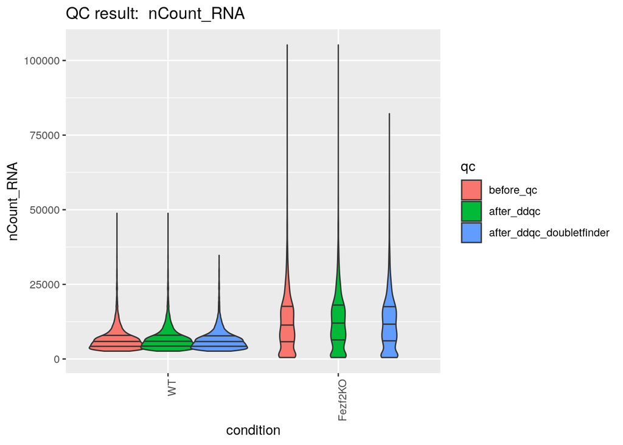

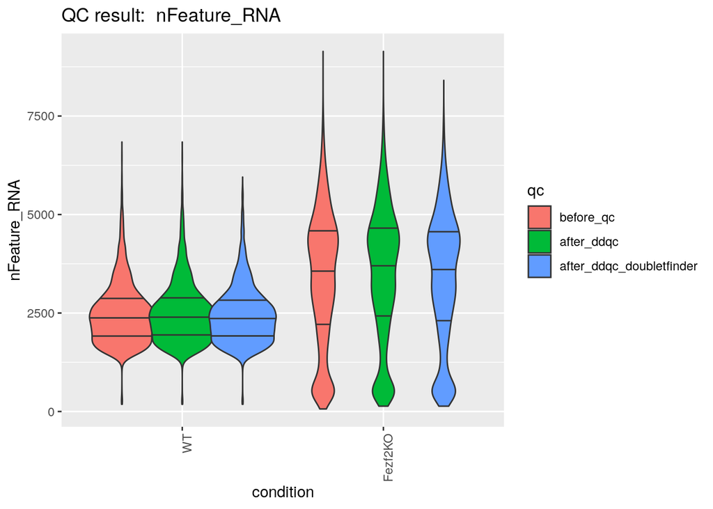

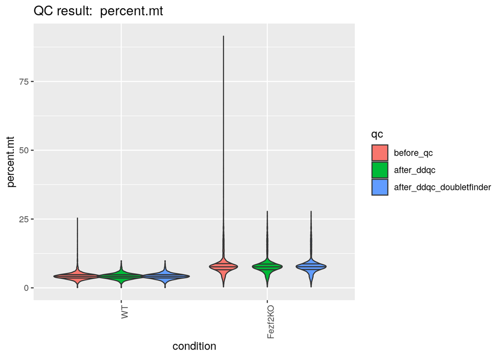

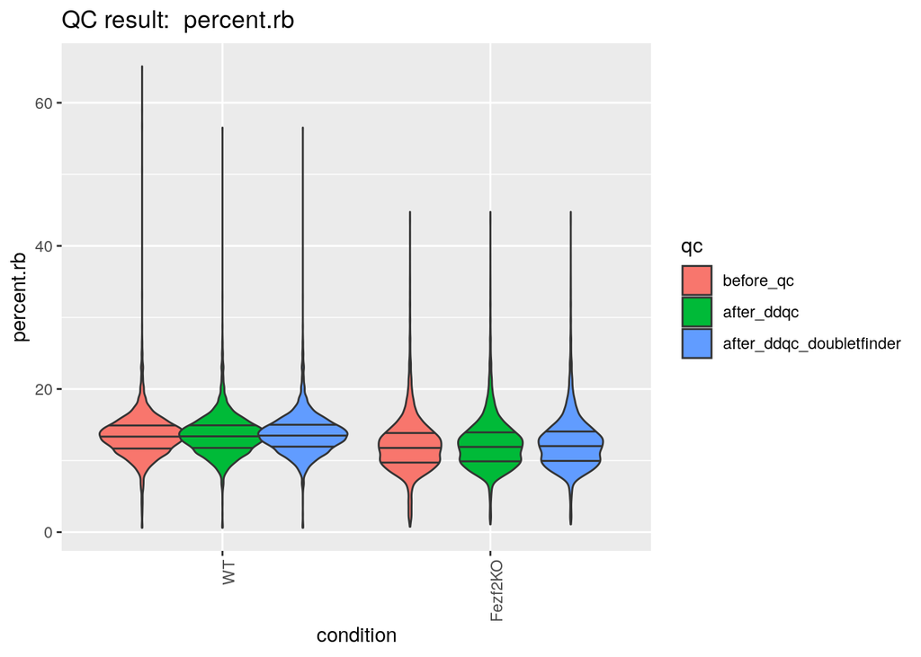

```r
# code:2-14
violinplot_list
```

##### Visualizing Changes in Gene and Cell Counts Using Bar Plots

Collect gene and cell count information from Seurat objects.

```r
# code:2-15
data_vec <- c("rawdata", "before_qc", "after_ddqc", "after_ddqc_doubletfinder")
# Collect gene and cell count information from Seurat objects.
gene_cell_pop_list <- list(
  as.data.frame(t(as.data.frame(lapply(orig_mtx_list, dim)))),
  as.data.frame(t(as.data.frame(lapply(created_seurat_obj_list, dim)))),
  as.data.frame(t(as.data.frame(lapply(ddqc_seurat_obj_list, dim)))),
  as.data.frame(t(as.data.frame(lapply(doubletfinder_ddqc_seurat_obj_list, dim))))
)
```

Prepare for Bar Plot visualization.

```r
# code:2-16
names(gene_cell_pop_list) <- data_vec
for(dtn in data_vec) {
  colnames(gene_cell_pop_list[[dtn]]) <- c("gene_number", "cell_number")
  gene_cell_pop_list[[dtn]] <-
    gene_cell_pop_list[[dtn]] %>%
    mutate(data_name = dtn)
  gene_cell_pop_list[[dtn]]["sample"] <- rownames(gene_cell_pop_list[[dtn]])
  row.names(gene_cell_pop_list[[dtn]]) <- NULL
}
gene_cell_pop_df <-
  do.call(bind_rows, gene_cell_pop_list) %>%
  mutate(data_name = factor(data_name, levels = c("rawdata", "before_qc", "after_ddqc", "after_ddqc_doubletfinder"))) %>%
  separate(col = sample, into = c("age", "area", "condition"), sep = "_") %>%
  mutate(condition = factor(condition, levels = c("WT", "Fezf2KO")))
```

Generate Bar Plots for gene and cell counts.

```r
# code:2-17
plot_vars <- c("gene_number", "cell_number")
barplot_list <- list()
for(var in plot_vars){
  target_var <- sym(var)  # 文字列をシンボルに変換
  barplot_list[[var]] <-
    ggplot(data = gene_cell_pop_df, mapping = aes(x = condition, y = {{ target_var }}, fill = data_name)) +
    geom_col(position = position_dodge()) +
    ggtitle(paste("QC result: ", var)) + # タイトルを追加
    theme(axis.text.x = element_text(angle = 90, hjust = 1))
}
```

Verify Bar Plots.

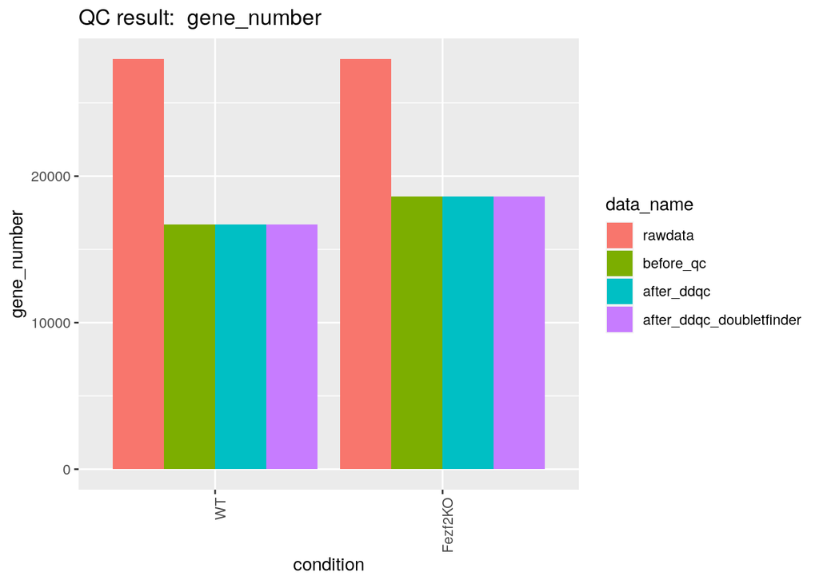

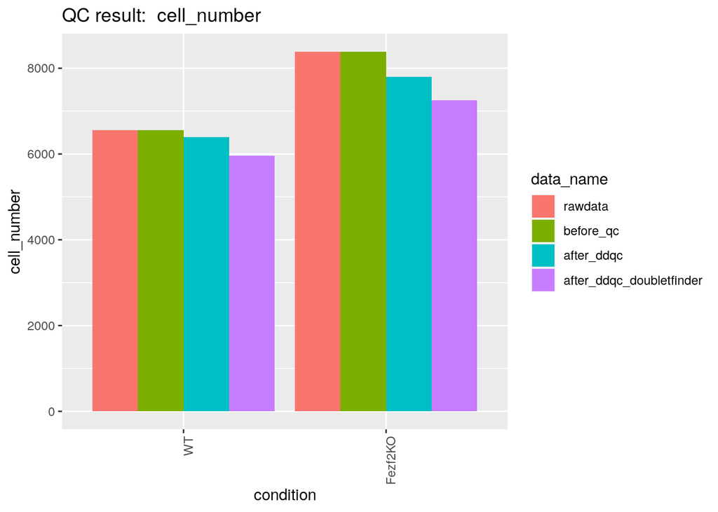

```r
# code:2-18
barplot_list
```

### Merging Seurat Objects

Merge all scRNA-seq data into a single Seurat object, with each dataset stored in a layer.

```r
# code:2-19
merged4norm_seurat_obj <- doubletfinder_ddqc_seurat_obj_list[[1]]
for (snm in names(doubletfinder_ddqc_seurat_obj_list)[2:length(doubletfinder_ddqc_seurat_obj_list)]) {
  merged4norm_seurat_obj <- merge(merged4norm_seurat_obj, doubletfinder_ddqc_seurat_obj_list[[snm]])
}
```

Save the merged Seurat object.

```r
# code:2-20
saveRDS(merged4norm_seurat_obj, "./output/02_quality_control/obj/merged4norm_seurat_obj.RDS")
```